# Lazyeval in base R

Stu Field

2022-01-08

### TL;DR

- promises special objects that are *unevaluated* expressions
- use `substitute()` to access the promised expression, but not evaluate it
- use `eval()` to evaluate the expression in a specific environment
- data frames are lists & lists are environments
- *all* function arguments are initially promises

#### Eval:

> “The expression given as function arguments are not evaluated before the function is called. Instead, the expressions are packaged together with the environment in which they should be evaluated and it is this package that is passed to the function. Evaluation only takes place when the argument is required.”

#### Promises:

> “Promise objects are part of `R`’s lazy evaluation mechanism. They contain three slots: a value, an expression, and an environment. When a function is called the arguments are matched and then each of the formal arguments is bound to a promise. The expression that was given for that formal argument and a pointer to the environment the function was called from are stored in the promise.”

#### Lazyeval

Lazy evaluation is a mechanism used by `R` (and many functional languages) to delay the evaluation of an object until it is needed. To do this, `R` has a data structure (object) called a “promise”, which is an un-evaluated expression, that can later be “fulfilled” by assigning it a value via evaluation in a given environment.

Lazy evaluation (and “tidyeval”) has and still remains a maddening, confusing, and veritable Dante’s Inferno of frustration for me. Every time I think I have it nailed down, it turns around and slaps me in the face and says: “oh no you don’t!”. It’s a constant “2 steps forward, and 1.9 steps back”. This is an attempt to consolidate lazyeval gains and understanding, to document what I currently know, and not have to start over every time I need to dive into the lazyeval world yet again.

### Examples of lazyeval

```r
f <- function(a, b) {
  # 'a' and 'b' are only promises, lazyeval means they are
  # only evaluated when asked for
  cat("Hello\n")
}
f()
```

```
#> Hello
```

```r
f <- function(a, b) {
  if ( TRUE ) {
    a
  } else {
    b
  }
}
f(4)
```

```
#> [1] 4
```

```r
f <- function(x) {
  if ( TRUE || x ) {   # x = promise that is never evaluated
    cat("Hello 1\n")
  }
  if ( TRUE | x ) {   # x = promise that IS evaluated -> Error
    cat("Hello 2\n")
  }
}
f()
```

```
#> Hello 1
#> Error in f(): argument "x" is missing, with no default
```

```r
# note that each argument evaluated only when asked for
ping <- function(a = Sys.time(), b = Sys.time(), c = Sys.time()) {
  print(a)
  Sys.sleep(1)
  print(b)
  Sys.sleep(2)
  print(c)
  invisible()
}
ping()
```

```
#> [1] "2022-01-08 20:18:44 MST"
#> [1] "2022-01-08 20:18:45 MST"
#> [1] "2022-01-08 20:18:47 MST"
```

### Leveraging lazyeval

> You can *intentionally* delay evaluation and evaluate it “on demand” when YOU want.

Until that argument is accessed there is no value associated with the promise. When the argument is accessed, the stored expression (symbol) is evaluated in the stored environment, and the result is returned. The result is also saved by the promise. The `substitute()` function will extract the content of the expression slot. This allows the programmer to access either the value OR the expression associated with the promise.

- `substitute()` captures a promise -> symbol
  - “expression slot extractor”
- `deparse()` converts expression/symbol -> character
- `eval()` evaluates the symbol in a given environment

True power of `substitute()` means you can capture a promise and evaluate it at a time and in a context of *your* choosing.

```r
f <- function(x) {
  subx <- substitute(x)   # no error! keeps promise intact
  print(subx)
  chr <- deparse(subx)
  print(chr)
  invisible()
}
f(foo)
```

```
#> foo
#> [1] "foo"
```

```r
f(1:10)
```

```
#> 1:10
#> [1] "1:10"
```

Now we can understand what functions like the `dplyr` verbs `pull()`, `mutate()` and `filter()` are doing under the hood:

```r
# simplified `dplyr::pull()`
pull2 <- function(.data, var) {
  expr <- substitute(var)      # 1st capture the promise
  # remember:
  #   1) data frames are lists
  #   2) lists can behave like environments!
  eval(expr, envir = .data)   # 2nd evaluate it in context of `.data`
}

pull2(mtcars, mpg)
```

```
#>  [1] 21.0 21.0 22.8 21.4 18.7 18.1 14.3 24.4 22.8 19.2 17.8 16.4 17.3 15.2 10.4 10.4 14.7 32.4 30.4
#> [20] 33.9 21.5 15.5 15.2 13.3 19.2 27.3 26.0 30.4 15.8 19.7 15.0 21.4
```

```r
# simplified `dplyr::mutate()`
mutate2 <- function(.data, expr_calc) {
  expr <- substitute(expr_calc)              # 1st capture the promise
  .data$new_var <- eval(expr, envir = .data) # 2nd evaluate it in context of `.data`
  .data
}

mutate2(head(mtcars), mpg * 2)
```

```
#>                    mpg cyl disp  hp drat    wt  qsec vs am gear carb new_var
#> Mazda RX4         21.0   6  160 110 3.90 2.620 16.46  0  1    4    4    42.0
#> Mazda RX4 Wag     21.0   6  160 110 3.90 2.875 17.02  0  1    4    4    42.0
#> Datsun 710        22.8   4  108  93 3.85 2.320 18.61  1  1    4    1    45.6
#> Hornet 4 Drive    21.4   6  258 110 3.08 3.215 19.44  1  0    3    1    42.8
#> Hornet Sportabout 18.7   8  360 175 3.15 3.440 17.02  0  0    3    2    37.4
#> Valiant           18.1   6  225 105 2.76 3.460 20.22  1  0    3    1    36.2
```

```r
# slightly more general `mutate2()`
mutate3 <- function(.data, ...) {
  dots <- substitute(list(...))
  vars <- names(dots)[-1L]
  for ( var in vars ) {
    .data[[var]] <- eval(dots[[var]], .data)
  }
  .data
}

mutate3(head(mtcars), mpg3x = mpg * 3, carb2 = carb ^ 2, vs_copy = gear)
```

```
#>                    mpg cyl disp  hp drat    wt  qsec vs am gear carb mpg3x carb2 vs_copy
#> Mazda RX4         21.0   6  160 110 3.90 2.620 16.46  0  1    4    4  63.0    16       4
#> Mazda RX4 Wag     21.0   6  160 110 3.90 2.875 17.02  0  1    4    4  63.0    16       4
#> Datsun 710        22.8   4  108  93 3.85 2.320 18.61  1  1    4    1  68.4     1       4
#> Hornet 4 Drive    21.4   6  258 110 3.08 3.215 19.44  1  0    3    1  64.2     1       3
#> Hornet Sportabout 18.7   8  360 175 3.15 3.440 17.02  0  0    3    2  56.1     4       3
#> Valiant           18.1   6  225 105 2.76 3.460 20.22  1  0    3    1  54.3     1       3
```

```r
# simplified `dplyr::filter()`
filter2 <- function(.data, ...) {
  lgl <- eval(substitute(...), .data)
  stopifnot(is.logical(lgl), length(lgl) == nrow(.data))
  .data[lgl, ]
}

filter2(mtcars, cyl == 8 & mpg > 15)
```

```
#>                    mpg cyl  disp  hp drat    wt  qsec vs am gear carb
#> Hornet Sportabout 18.7   8 360.0 175 3.15 3.440 17.02  0  0    3    2
#> Merc 450SE        16.4   8 275.8 180 3.07 4.070 17.40  0  0    3    3
#> Merc 450SL        17.3   8 275.8 180 3.07 3.730 17.60  0  0    3    3
#> Merc 450SLC       15.2   8 275.8 180 3.07 3.780 18.00  0  0    3    3
#> Dodge Challenger  15.5   8 318.0 150 2.76 3.520 16.87  0  0    3    2
#> AMC Javelin       15.2   8 304.0 150 3.15 3.435 17.30  0  0    3    2
#> Pontiac Firebird  19.2   8 400.0 175 3.08 3.845 17.05  0  0    3    2
#> Ford Pantera L    15.8   8 351.0 264 4.22 3.170 14.50  0  1    5    4
```

### Detecting promises

From the `R` manual:

> Within the R language, promise objects are almost only seen implicitly: actual function arguments are of this type. There is also a `delayedAssign()` function that will make a promise out of an expression. There is generally **no way in R code to check whether an object is a promise or not,** **nor is there a way to use R code to determine the environment of a promise.**

So it appears you can *create* a promise, but not detect whether an object is a promise or not. Boo! :(

### Forcing promises

To “force” a promise is nothing more than to assign a value to the promise slot via evaluation. This can be accomplished either by calling the promise variable, or by using the `force()` function.

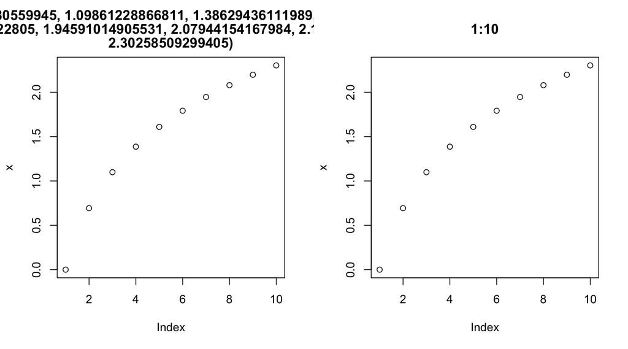

```r
par(mfrow = 1:2)
f <- function(x, y = deparse(substitute(x))) {
  x <- log(x)
  plot(x, main = y) # 'y' is forced AFTER 'x' has changed
  invisible()
}
f(1:10)

# we can force 'y' first
f2 <- function(x, y = deparse(substitute(x))) {
  force(y)
  x <- log(x)
  plot(x, main = y)
  invisible()
}
f2(1:10)
```

### Resources

- [Roots of quotation](https://milesmcbain.xyz/posts/the-roots-of-quotation/)
- [r-bloggers: About lazy evaluation](https://www.r-bloggers.com/2018/07/about-lazy-evaluation/)